# STATS 32 Session 8: Common questions and useful packages

Damian Pavlyshyn

May 7, 2020

# Agenda for today

Topics that I have had repeated questions about and that are of general utility for the project and data processing in general.

- Splitting and combining columns
- Working with dates
- Lines of best fit and more
- Handling missing data

```r
library(tidyverse)
```

# Splitting columns

Often, when we load a dataset, the variables will not be split neatly into columns, and instead, multiple pieces of information will be contained in a single column.

For example, in the following dataset, the `name` columns contains first and last names, which we might want in separate columns:

```r
df <- tibble(
    name = c("Frodo Baggins", "Peregrin Took", "Aragorn", "Gandalf"),
    height = c("4'", "4' 7\"", "6' 6\"", "5' 11\""),
    father = c("Drogo", "Paladin", "Arathorn", NA)
)
```

```
## # A tibble: 4 x 3
##   name          height    father
##   <chr>         <chr>     <chr>
## 1 Frodo Baggins "4'"      Drogo
## 2 Peregrin Took "4' 7\""  Paladin
## 3 Aragorn       "6' 6\""  Arathorn
## 4 Gandalf       "5' 11\"" <NA>
```

This is done with the `separate()` function, which splits a string into discrete bits that are continuous chunks of letters and numbers:

```r
df <- df %>%
    separate(name, c("firstname", "lastname"))
```

```
## # A tibble: 4 x 4
##   firstname lastname height    father
##   <chr>     <chr>    <chr>     <chr>
## 1 Frodo     Baggins  "4'"      Drogo
## 2 Peregrin  Took     "4' 7\""  Paladin
## 3 Aragorn   <NA>     "6' 6\""  Arathorn
## 4 Gandalf   <NA>     "5' 11\"" <NA>
```

You can manually specify the `sep=` parameter to only split along certain characters. This is useful, for example, if you want to spit at commas, but not at spaces

# Advanced column splitting with regular expressions

Often, columns contain multiple pieces of information that are not just next to each other, but encoded in a more complicated way. Consider the `height` column in the following dataframe, which is formatted as feet and inches.

```
## # A tibble: 4 x 4
##   firstname lastname height    father
##   <chr>     <chr>    <chr>     <chr>
## 1 Frodo     Baggins  "4'"      Drogo
## 2 Peregrin  Took     "4' 7\""  Paladin
## 3 Aragorn   <NA>     "6' 6\""  Arathorn
## 4 Gandalf   <NA>     "5' 11\"" <NA>
```

For more complicated specifications, we use a function called `extract()` together with a format specification string called a “regular expression”. (It turns out that `separate()` works here as well, but this works as a relatively simple example of `extract()`)

Regular expressions are strings specify the **format** of a string, while keeping its content generic. This allows us to extract parts of a formatted string for later use.

Regular expressions are extremely useful in almost any domain of computation, so do yourself a favour and spend a few hours learning them on websites such as https://regexone.com/ and https://regexr.com/.

Without going into much detail, the regex string `"([0-9]+)' ([0-9]+)"` specifies a format that is `"<some numbers>' <some other numbers>"`, and the parentheses indicate that we should keep track of the numbers. Let’s see this in action:

```r
df %>%
    extract(height, c("height_feet", "height_inches"), regex = "([0-9]+)' ([0-9]+)")
```

```
## # A tibble: 4 x 5
##   firstname lastname height_feet height_inches father
##   <chr>     <chr>    <chr>       <chr>         <chr>
## 1 Frodo     Baggins  <NA>        <NA>          Drogo
## 2 Peregrin  Took     4           7             Paladin
## 3 Aragorn   <NA>     6           6             Arathorn
## 4 Gandalf   <NA>     5           11            <NA>
```

This isn’t bad, but not exactly what we want. The resulting columns are characters, so we should supply the `convert=TRUE` argument to `extract()` to convert them to numbers.

Moreover, Frodo’s height has not been matched, since `"4'"` doesn’t have the inches part. The modified regex string `"([0-9]+)' ?([0-9]*)"` makes matching the second number optional - *I strongly recommend that you learn enough about regex that you understand why!*

```r
df %>%
    extract(height, c("height_feet", "height_inches"), regex = "([0-9]+)' ?([0-9]*)", convert=TRUE)
```

```
## # A tibble: 4 x 5
##   firstname lastname height_feet height_inches father
##   <chr>     <chr>          <int>         <int> <chr>
## 1 Frodo     Baggins            4            NA Drogo
## 2 Peregrin  Took               4             7 Paladin
## 3 Aragorn   <NA>               6             6 Arathorn
## 4 Gandalf   <NA>               5            11 <NA>
```

Much better!

A zero value is better than `NA` for Frodo’s `height_inches`, and perhaps we want to convert the heights to centimetres. We can achieve both of these modifications with a single `mutate()`:

```r
df <- df %>%
    extract(height, c("height_feet", "height_inches"), regex = "([0-9]+)' ?([0-9]*)", convert=TRUE) %>%
    mutate(
        height_inches = replace_na(height_inches, 0),
        height_cm = (12 * height_feet + height_inches) * 2.54
    )
```

```
## # A tibble: 4 x 6
##   firstname lastname height_feet height_inches father   height_cm
##   <chr>     <chr>          <int>         <dbl> <chr>        <dbl>
## 1 Frodo     Baggins            4             0 Drogo         122.
## 2 Peregrin  Took               4             7 Paladin       140.
## 3 Aragorn   <NA>               6             6 Arathorn      198.
## 4 Gandalf   <NA>               5            11 <NA>          180.
```

# Combining columns

If we can split columns into constituent parts, we should also be able to combine them together. We do this with the `unite()` function.

Tolkien likes to refer to his characters in the patronymic form “Aragorn, son of Arathorn”, so let’s try to create this from our data table:

```r
df %>%
    unite("patronymic", c("firstname", "father"))
```

```
## # A tibble: 4 x 5
##   patronymic       lastname height_feet height_inches height_cm
##   <chr>            <chr>          <int>         <dbl>     <dbl>
## 1 Frodo_Drogo      Baggins            4             0      122.
## 2 Peregrin_Paladin Took               4             7      140.
## 3 Aragorn_Arathorn <NA>               6             6      198.
## 4 Gandalf_NA       <NA>               5            11      180.
```

This is a good start, but there are several things wrong:

- The separator between `firstname` and `lastname` is `"_"`, whereas we would like it to be `", son of "` instead.
- Being an immortal being, Gandalf has no father, so we don’t want to add anything on to his name.
- By default, `unite()` removes the constituent columns, whereas we probably want to hold on to them.

All of these problems can be easily addressed with keyword arguments passed to `unite()`:

```r
df <- df %>%
    unite("patronymic", c("firstname", "father"),
          sep = ", son of ",
          na.rm = TRUE,
          remove = FALSE)
```

```
## # A tibble: 4 x 7
##   patronymic       firstname lastname height_feet height_inches father height_cm
##   <chr>            <chr>     <chr>          <int>         <dbl> <chr>      <dbl>
## 1 Frodo, son of D… Frodo     Baggins            4             0 Drogo       122.
## 2 Peregrin, son o… Peregrin  Took               4             7 Palad…      140.
## 3 Aragorn, son of… Aragorn   <NA>               6             6 Arath…      198.
## 4 Gandalf          Gandalf   <NA>               5            11 <NA>        180.
```

```r
df %>% select(patronymic)
```

```
## # A tibble: 4 x 1
##   patronymic
##   <chr>
## 1 Frodo, son of Drogo
## 2 Peregrin, son of Paladin
## 3 Aragorn, son of Arathorn
## 4 Gandalf
```

This is exactly what we wanted!

# `stat_summary` aesthetics in ggplot

The usual `geom_` objects of `ggplot` place visuals on the canvas based on the variable values of each tabled row.

Often, we want to plot things computed from the data, (such as aggregated means) directly instead of going through the hassle of creating a new dataframe containing those values.

`ggplot` objects starting with `stat_` work by first summarising variables in some way, and then plotting the result.

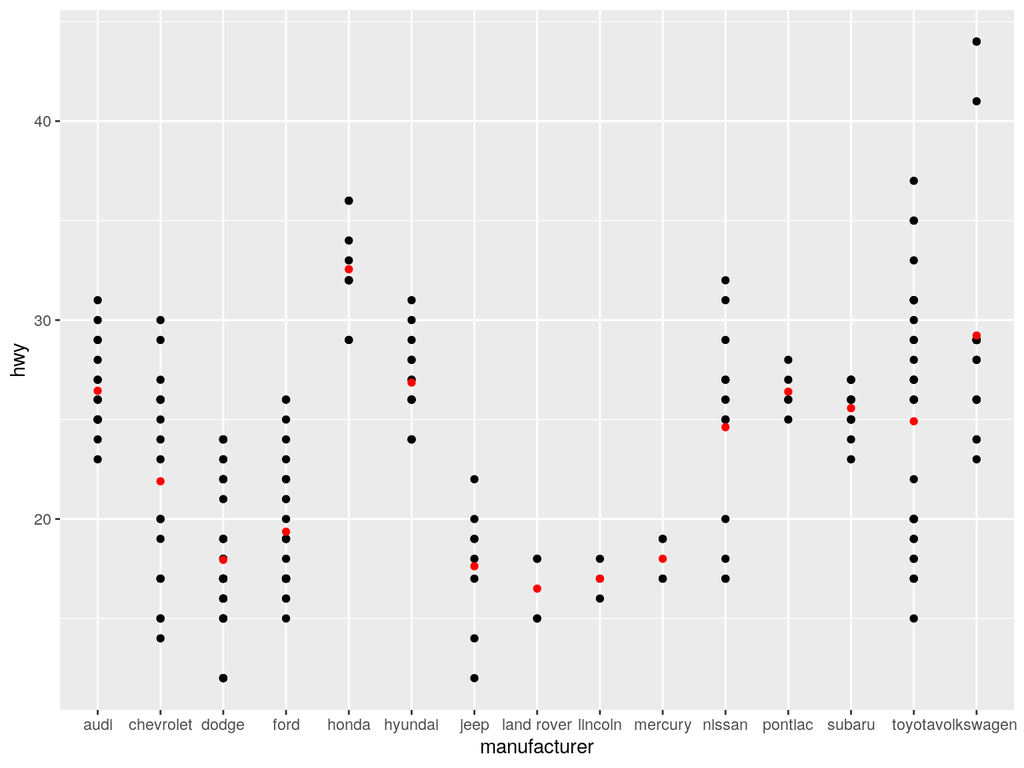

```r
ggplot(mpg, aes(x = manufacturer, y = hwy)) +
    geom_point() +
    stat_summary(fun = mean, geom="point", color="red")
```

Since `manufacturer` is a factor, `stat_summary()` has grouped the data by manufacturer and computed the mean efficiency by manufacturer.

Even though this mean doesn’t appear in any data table, it is still plotted to the canvas.

`stat_summary()` takes the same sort of arguments as regular `geom_` objects, including aesthetic mappings.

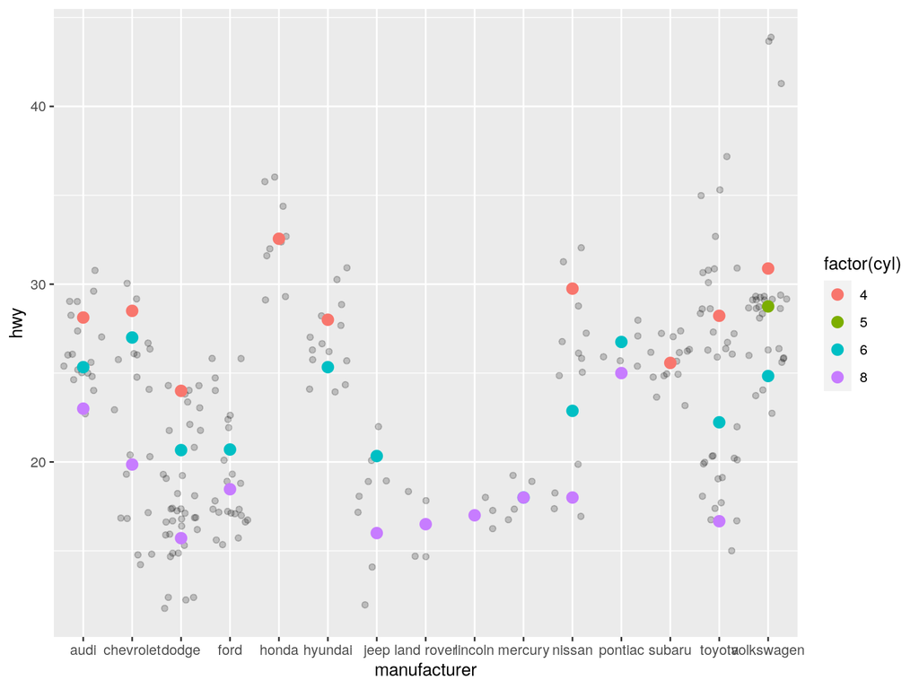

```r
ggplot(mpg, aes(x = manufacturer, y = hwy)) +
    geom_point(position="jitter", alpha=0.2) +
    stat_summary(
        fun = mean,
        mapping = aes(color=factor(cyl)),
        size = 3,
        geom="point")
```

`stat_summary()` understands all sorts of functions, and you can find such functions in-built as well as in external packages.

Here, we see a function that produces bootstrapped confidence intervals for the mean (if you don’t understand this, I recommend taking some applied stats courses!)

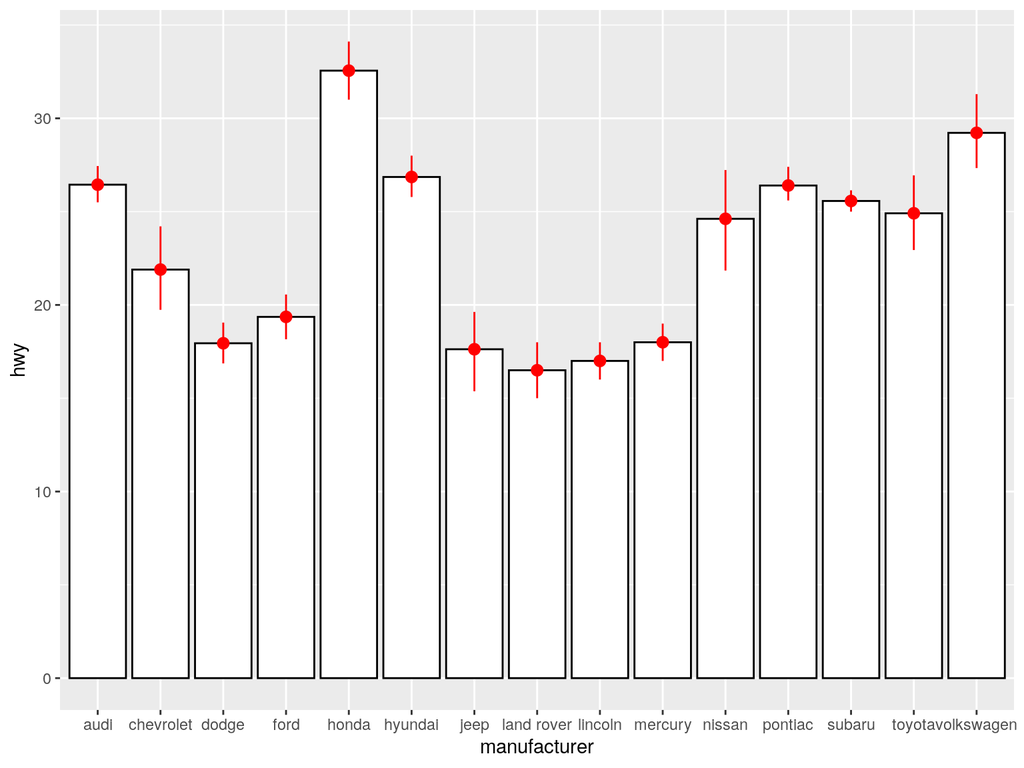

```r
library(Hmisc)
ggplot(mpg, aes(x = manufacturer, y = hwy)) +
    stat_summary(fun = mean, geom="bar", fill="white", color="black") +
    stat_summary(fun.data = "mean_cl_boot", color="red")
```

# `stat_smooth`: interpolation and lines of best fit

Other common transformations for out data are interpolations. These allow us to fit a smooth curve to potentially messy and noisy data to summarise an overall trend.

The function for this is `stat_smooth()`. By default, it fits a curve to our data:

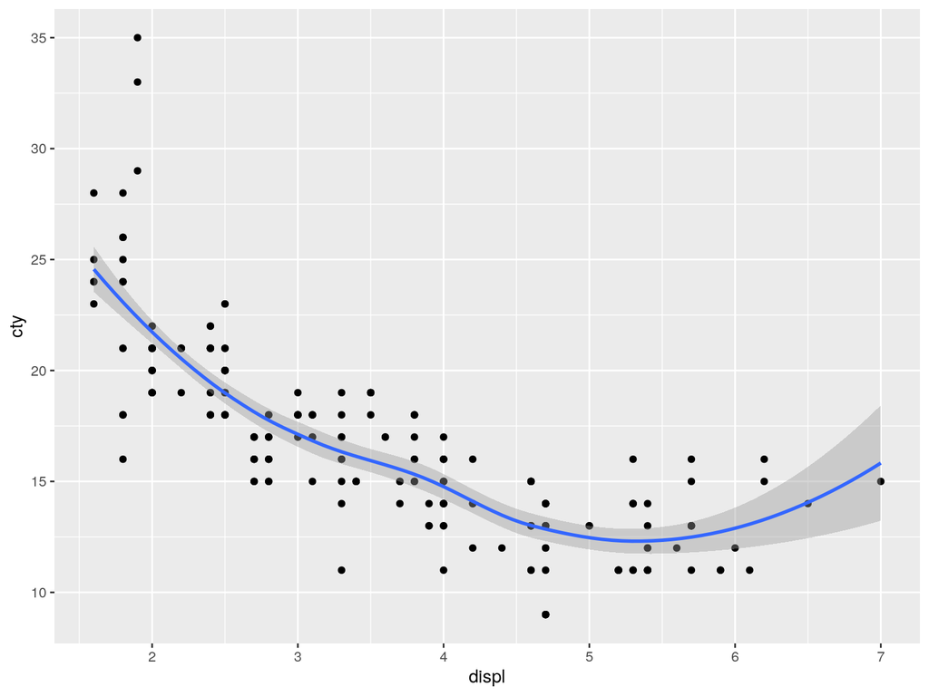

```r
ggplot(mpg, aes(x = displ, y = cty)) +
    geom_point() +
    stat_smooth()
```

Often, a curve will overfit, and we prefer to fit only straight lines. This is done by supplying the `method = "lm"` (lm stands for linear model) option to the `stat_smooth()` function.

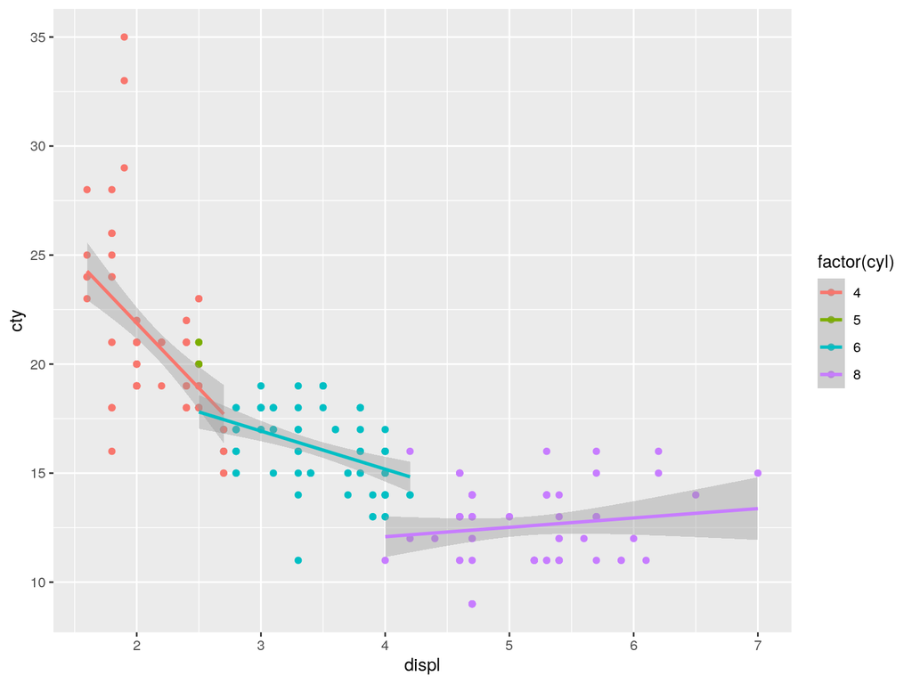

```r
ggplot(mpg, aes(x = displ, cty, color = factor(cyl))) +
    geom_point() +
    stat_smooth(method = "lm")
```

As we see in the above, `stat_smooth()` inherits aesthetics from the `ggplot()` call, so in this case, we have three different lines of best fit.

If that’s what we want, then great! Otherwise, we need to make sure not to pass `stat_smooth()` a grouping aesthetic.

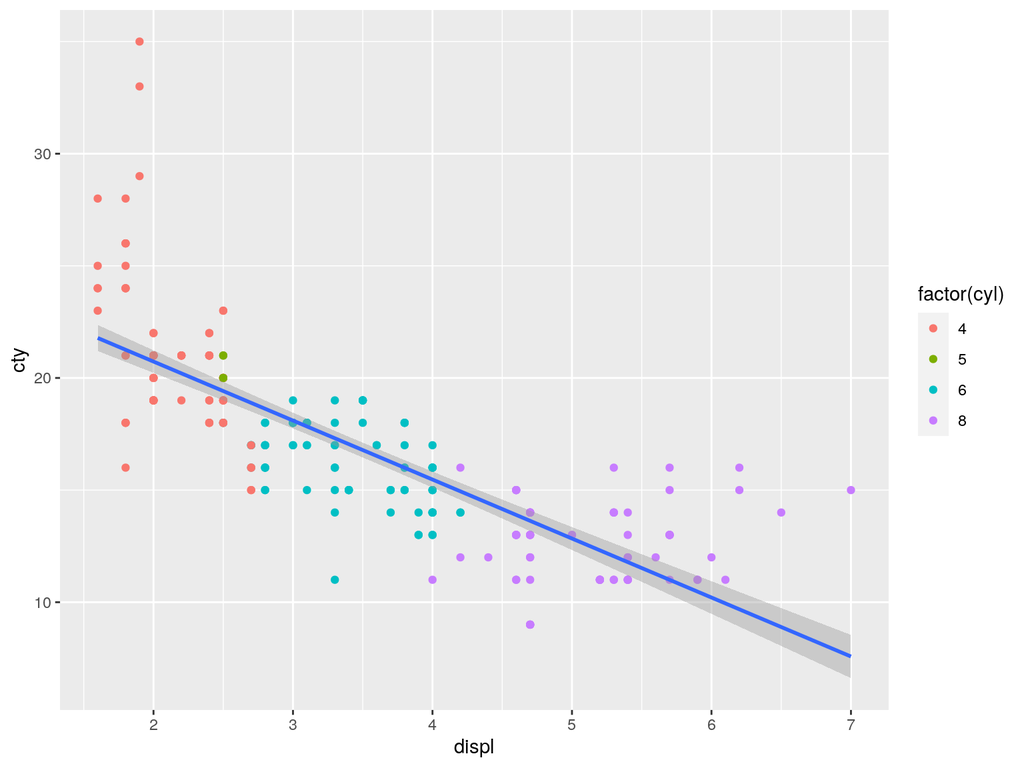

```r
ggplot(mpg, aes(x = displ, cty)) +
    geom_point(aes(color = factor(cyl))) +
    stat_smooth(method = "lm")
```

# `lubridate` and parsing dates

Working with dates and times is generally an *enormous* headache - different parts of the world have different formats, we have distinctions between 12 and 24-hour times and every dataset seemingly has a different way of recording this information.

In a dataset, the **ONE TRUE FORMAT** for recording dates is year-month-day, so that today’s date is `2020-05-07`. You should *always* record dates in this standard format and *always* immediately convert dates in any other format to this one.

Our main tool for this is a library called `lubridate`:

```r
library(lubridate)
```

A comprehensive specification of `lubridate`’s functionality is found here: https://evoldyn.gitlab.io/evomics-2018/ref-sheets/R_lubridate.pdf, but here are some examples:

```r
mdy("5/7/20")
```

```
## [1] "2020-05-07"
```

```r
dmy("7th of May 2020")
```

```
## [1] "2020-05-07"
```

```r
ymd(20200507)
```

```
## [1] "2020-05-07"
```

```r
today()
```

```
## [1] "2020-05-06"
```

As you can see, this is very flexible, and saves many headaches!

# Parsing times and dates

For date and time data, the **ONE TRUE FORMAT** is “year-month-day hour:minute:second”, where the hour is recorded in 24-hour time.

For example, the final project is due on `2020-05-16 23:59:59`, with the hyphens, spaces and colons in exactly that order.

The `lubridate` functions for parsing datetimes are analogous to those for dates:

```r
dmy_hm("16/5/2020, 11.59 PM")
```

```
## [1] "2020-05-16 23:59:00 UTC"
```

```r
ymd_hms("20~5~16 23:59.59")
```

```
## [1] "2020-05-16 23:59:59 UTC"
```

```r
now()
```

```
## [1] "2020-05-06 17:04:55 PDT"
```

We can also parse arbitrarily terrible formats:

```r
parse_date_time("AM 59:12, 59 16-2020, 5", "pMhsdym")
```

```
## [1] "2020-05-16 00:59:59 UTC"
```

The `UTC` refers to “Coordinated Universal Time,” which is basically Greenwich Mean Time. To be precise, we should specify the timezone of out project due date:

```r
due_date <- ymd_hms("2020-05-16 23:59:59", tz = "PST")
```

[output not shown]

# Making use of the standard format

Once we have our due date in the **ONE TRUE FORMAT**, we can extract all kinds of information about it:

```r
month(due_date)
```

```
## [1] 5
```

```r
dst(due_date)
```

```
## [1] FALSE
```

```r
leap_year(due_date)
```

```
## [1] TRUE
```

We can also do timezone conversions:

```r
with_tz(due_date, "Universal")
```

```
## [1] "2020-05-17 07:59:59 UTC"
```

```r
with_tz(due_date, "Australia/Melbourne")
```

```
## [1] "2020-05-17 17:59:59 AEST"
```

# Dealing with missing data

R records missing values of any type as the special value `NA`. Be aware that there are other non-values, such as `Inf` and `NaN`. These have the double type, and occur as outputs to mathematical operations.

## Operations with `NA`s

`NA`s represent missing values - that is, data that we don’t know. Thus, any operation including an `NA` will produce an `NA`

```r
1 + NA
```

```
## [1] NA
```

```r
NA - NA
```

```
## [1] NA
```

```r
NA * 0
```

```
## [1] NA
```

```r
1 == NA
```

```
## [1] NA
```

```r
NA == NA
```

```
## [1] NA
```

To check if a value missing, instead use the `is.na()` function:

```r
is.na(c(1, 2, 3, NA, 5, 6, NA))
```

```
## [1] FALSE FALSE FALSE  TRUE FALSE FALSE  TRUE
```

# Introducing, filling and removing `NA`s

```r
df <- tibble(
    index = c(1, 2, 3),
    x = c(11, NA, 13),
    y = c("Yes", "No", ""))
```

```
## # A tibble: 3 x 3
##   index     x y
##   <dbl> <dbl> <chr>
## 1     1    11 "Yes"
## 2     2    NA "No"
## 3     3    13 ""
```

We can replace `NA`s with a specific value or vise-versa with the `replace_na()` and `na_if()` functions respectively:

```r
df %>%
    mutate(
        x = replace_na(x, 0),
        y = na_if(y, ""))
```

```
## # A tibble: 3 x 3
##   index     x y
##   <dbl> <dbl> <chr>
## 1     1    11 Yes
## 2     2     0 No
## 3     3    13 <NA>
```

We can call this function on the whole dataframe:

```r
df <- na_if(df, "")
```

```
## # A tibble: 3 x 3
##   index     x y
##   <dbl> <dbl> <chr>
## 1     1    11 Yes
## 2     2    NA No
## 3     3    13 <NA>
```

We can remove rows with missing values using the `drop_na()` function on the whole data table, or only on some columns:

```r
drop_na(df)
```

```
## # A tibble: 1 x 3
##   index     x y
##   <dbl> <dbl> <chr>
## 1     1    11 Yes
```

```r
drop_na(df, index, y)
```

```
## # A tibble: 2 x 3
##   index     x y
##   <dbl> <dbl> <chr>
## 1     1    11 Yes
## 2     2    NA No
```

# Overview of the course

1. Basic structure of a dataset - rows denote observations, columns denote variables
2. Data and variable types - strings, doubles, booleans, factors
3. Plotting with `ggplot` - made up of data, aesthetic mapping and geoms
4. Data transformation - the five `dplyr` verbs, grouping and piping
5. Data files and RMarkdown - locating file paths and changing working directory
6. Combining data tables with joins - identify the rows and columns you want in your resulting table before running anything!
7. Grouped `geom_polygon`s and making maps

**Thanks for your attention and for taking stats32!**